# Logistic Regession

F.A. Barrios

2020-11-21

# Examples from the CAR book (Fox & Weisberg) [^1]

## Review of the Structure of GLMs

The structure of a GLM is very simiar to that of the linear model. In partiular we have a response variable $y$ and $m$ predictors, and we are interested in undestanding how the mean of $y$ varies as the values of the predictors change.

```r
library(tidyverse)
library(here)
library(wesanderson)
library(rstatix)
library(HSAUR2)
library(car)
library(multcomp)

setwd("~/Dropbox/GitHub/Class2020")
wcgs <- read_csv("DataRegressBook/Chap2/wcgs.csv")
```

A GLM consists of three components

1. Random component, specifying the conditional or “error” distribution of the response variable, $y$, given the predictors from an *exponential family*. Both the binomial and Poisson distributions ae in the class of explonential families, and so problems with categorical or discrete responses can be studied with GLMs.
2. As in linear models, the $m$ predictors in a GLMare translated into a vector of $k + 1$ regressor varibles, ${\bf x} = (x_0, x_1, \dots , x_k)$, possibly using contrast regressors for factors, polynomials, regression splines, transformations, and interactions. The response depends on the predictors only through a linear function of the regressors, called the *linear predictor*,
   $$\eta({\bf x}) = \beta_0 + \beta_1 x_1 + \cdots + \beta_k x_k$$
3. The connection between the conditional mean $E[y|{\bf x}]$ of the response and the predictor $\eta({\bf x})$ in a linear model is direct,
   $$E[y|{\bf x}] = \eta({\bf x}) = \beta_0 + \beta_1 x_1 + \cdots + \beta_k x_k$$
   and so the mean is equal to a linear combination of the regressors. This direct relationshi is not appropriate for all GLM because $\eta({\bf x})$ can take any value, whereas the mean of a binary response variable must be in the interval (0,1). Therefore we introduce an invertible *link function g* that translates from the scale of the mean response to the scale of the linear predictor. $\eta({\bf x}) = E[y|{\bf x}]$ is standard in the GLM for the conditional mean of the response, therfore
   $$g[\mu({\bf x})] = \eta({\bf x})$$
   Reversing this relationship produces the *inverse-link function*, $g^{-1}[\eta(\bf {x})] = \mu(\bf {x})$. THe inverse of the link function is sometimes is sometimes called the *mean link funcion*

Standard link functions and their inverses table: $\mu = E[y|\bf x]$ is the expected value of the response; $\eta = \beta_0 + \beta_1 x_1 + \cdots + \beta_k x_k$ is the linear predictor.
$$\begin{array}{cccc}
\bf Link & {\bf \eta = g(\mu)} & {\bf \mu = g^{-1}(\eta)} & \bf Inverse Link \\
identity & \mu & \eta & identity \\
log & \log(\mu) & e^\eta & exponential \\
inverse & \mu^{-1} & \eta^{-1} & inverse \\
inverse square & \mu^{-2} & \eta^{-1/2} & inverse square root \\
square root & \sqrt{\mu} & \eta^{2} & square \\
logit & \log\frac{\mu}{1-\mu} & \frac{1}{1+e^{-\eta}} & logistic \\
probit & \Phi(\mu) & \Phi^{-1}(\eta) & normal quantile \\
comp. log-log & \log[-\log(-\mu)] & 1- \exp[-\exp(\eta)] & -
\end{array}$$

And the table for canonical or default link, response range, and conditional variance function for GLM families.
$$\begin{array}{cccc}
\bf{Family} & {\bf Default Link} & {\bf Range of y} & {\bf Var}(y|{\bf x}) \\
gaussian & identity & (-\infty, +\infty) & \phi \\
binomial & logit & \frac{0,1,\dots, N}{N} & \frac{\mu(1-\mu)}{N} \\
poisson & log & 0,1,\dots & \mu \\
Gamma & inverse & (0,\infty) & \phi \mu^2 \\
Inverse.gaussian & \frac{1}{\mu^2} & (0,\infty) & \phi \mu^3
\end{array}$$

The variance distributions of an exponential family is a product of a positive *dipersion (scale)* parameter $\phi$ and a function of the mean given the linear predictor:
$$Var(y|{\bf x}) = \phi \times V[\mu({\bf x})]$$
The variances for several exponential families are listed in the table above.

The *deviance*, based on the maximized value of the log-likelihood, provides a measure of the fit of a GLM to the data, much as the residual sum of squares does for a linear model.

# GLMs for Binary Responce Data

Comparison of the login, probit, and complementary log-log links

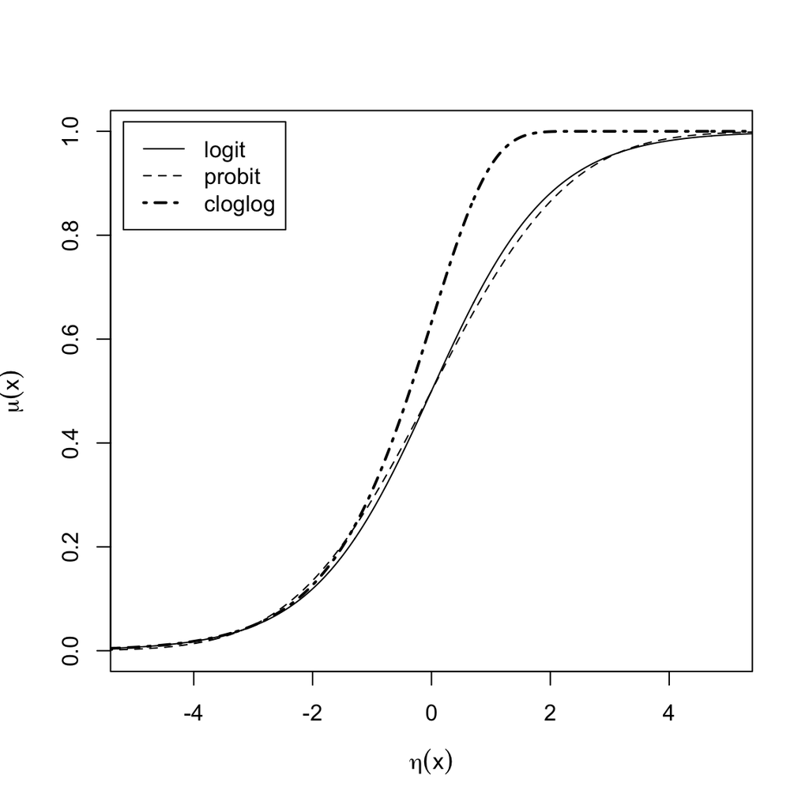

```r
# Example from the car Book Chp 6
Probit <- binomial(link=probit)
Logit <- binomial(link=logit)
Cloglog <- binomial(link=cloglog)
range <- seq(-10,10,length=1000)
plot(range,Logit$linkinv(range),type="l", xlim=c(-5,5), lty=1,
       xlab=expression(eta(x)), ylab=expression(mu(x)))
lines(sqrt(pi^2/3)*range, Probit$linkinv(range), lty=2)
lines(range,Cloglog$linkinv(range), lty=4, lwd=2)
legend("topleft",c("logit", "probit", "cloglog"), lty=c(1,2,4),
       lwd=c(1,1,2), inset=0.02)
```

[^1]: All notes are taken form the “Companion to Applied Regression”, 3^0 Ed. Fox & Weisberg